# Lesson 9

VIcki Hertzberg

3/11/2017

## Housekeeping

We are changing things up the next couple of weeks. These changes include new due dates as follows:

| Assignment | Due |
| --- | --- |
| HW5 | Today |
| HW6 | March 22 |
| Milestone 2 | March 29 |

And we are are going to adjust the topics for the class as follows:

| Date | Topic |
| --- | --- |
| Today | Machine Learning - Supervised Techniques |
| 3/22 | Machine Learning - Unsupervised Techniques |
| 3/29 | The Microbiome - fastq file to otu table to result |
| 4/5 | Continuation of 3/29 plus function plus AWS |
| 4/12 | Wrap up then free to do project work |
| 4/19 | Project presentations |
| 4/26 | Project presentations continued |

Questions?

As we are getting started, you will need to install and load the following R packages:

- rpart
- partykit
- tidyverse
- faraway
- randomForest

## Machine Learning: Supervised Techniques

Our goal is to predict some outcome variable, Y, from a set of independent variables,

$$\begin{equation}
\{ X_1, X_2, ..., X_p \}
\end{equation}$$

Let’s think back to linear regression. We have a basic model

$$\begin{equation}
Y = \beta_0 + \beta_1 X_1 + ... + \beta_p X_p
\end{equation}$$

Our goal is to have the fewest independent variables while maintaining a good predictive capacity.

Linear regression has several advantages:

- There is very nice theory going along with it.
- It scales well.

But these advantages do not come without a price:

- It is only one type of model (or function) for the mean
- Yet the space of possible model forms is infinite.

With *machine learning* the idea is that a model can be tuned to a specific data set. This term arose in the 1950’s for a set of techniques to extract as much information as possible from a dataset without human intervention. Nowdays we search for good models where good means:

- the model makes accurate predictions; and
- the model scales well.

This is not to say that regression is obsolete, because it is still the starter model.

As mentioned above there are two types of machine learning:

- Supervised: we model a particular response as a funciton of some explanatory variables
- Unsupervised: we find patterns or groupings where there exists no clear response variables.

Today we are talking about supervised learning. In this case we want to identify the function that that describes the relationship between inputs and outputs, kind of like a black box. For instance,

- you can use season as input and outdoor temperature as output
- you can use latitude and day of the year as input and outdoor temperature as output

So suppose we have successive ozone readings, but we also have some other information and we want to choose from a set of independent variables.

One way that we can choose the independent variables is to create a *regression tree* such that the variables split the space into a series of partitions where the outcome variables are more and more alike.

Well that certainly sounds like a big mess, doesn’t it?

This technique is called *recursive partitioning* and it enables exploring the data space, making it easier to visualize decision rules of for a continuous outcome (a regression tree), like we are examining here, or for a categorical outcome (a decision tree), like we will talk about in a bit.

One R tool that makes this a lot easier to implement is the package called rpart, and we will load it now.

```r
library(rpart)
library(tidyverse)
```

We will proceed in a stepwise manner.

1. Grow the tree.
2. Explore the results.
3. Prune the tree.

### 1. Grow the Tree

To grow the tree we will use the command

*rpart*(*formula*, *data =*, *method =*, *control =*) where

- *formula* is in the format Y ~ X1 + X2 + … + Xp Note: This is NOT a linear model. “+” only means to include variable for consideration.
- *data =* specifies the data frame
- *method = “anova”* for a regression tree
- *method = “class”* for a decision tree
- *control =* a series of optional parameters that controls the process of tree growth.

The output is an object called *fit*.

### 2. Explore the Results

We can use the following functions to examine the results.

| Function | Description |
| --- | --- |
| printcp(fit) | display the cp table |
| plotcp(fit) | plot cross-validation results |
| rsp.rpart(fit) | plot approx. R-squared for 2 different splits |
| print(fit) | print results |
| summary(fit) | detailed results including surrogate splits |
| plot(fit) | plot decision tree |
| text(fit) | label the decision tree plot |

### 3. Prune Tree

We will want to prune the tree in order to avoid overfitting the data. We will select the tree size the minimizes the cross-validated error (see the *xerror* column printed with *printcp(fit)*). We will then prune to the desired size using

*prune(fit, cp=)*

Specifically you use *printcp()* to select the complexity parameter associated with the minimum error, then place it into the *prune()* function.

#### Example

We are going to explore the *ozone* dataset that comes as part of the *faraway* package. We want to predict Ozone from the other variables, but we are going to do it by partitioning the space. First let’s load up the dataset and name see what’s what.

```r
library(faraway) #Install to get access to the  dataset
```

The variable names are as follows:

| Variable Name | Description |
| --- | --- |
| O3 | Daily Ozone Level |
| vh | Pressure height |
| wind | Wind speed at LAX |
| temp | Temperature |
| ibh | Inversion base height |
| dpg | Pressure gradient |
| ibt | Inversion base temp |
| vis | Visibility at LAX |
| doy | Day of year |

Let’s take a look:

```r
summary(ozone)  # What does the dataset look like?
```

```
##        O3              vh            wind           humidity
##  Min.   : 1.00   Min.   :5320   Min.   : 0.000   Min.   :19.00
##  1st Qu.: 5.00   1st Qu.:5690   1st Qu.: 3.000   1st Qu.:47.00
##  Median :10.00   Median :5760   Median : 5.000   Median :64.00
##  Mean   :11.78   Mean   :5750   Mean   : 4.848   Mean   :58.13
##  3rd Qu.:17.00   3rd Qu.:5830   3rd Qu.: 6.000   3rd Qu.:73.00
##  Max.   :38.00   Max.   :5950   Max.   :11.000   Max.   :93.00
##       temp            ibh              dpg              ibt
##  Min.   :25.00   Min.   : 111.0   Min.   :-69.00   Min.   :-25.0
##  1st Qu.:51.00   1st Qu.: 877.5   1st Qu.: -9.00   1st Qu.:107.0
##  Median :62.00   Median :2112.5   Median : 24.00   Median :167.5
##  Mean   :61.75   Mean   :2572.9   Mean   : 17.37   Mean   :161.2
##  3rd Qu.:72.00   3rd Qu.:5000.0   3rd Qu.: 44.75   3rd Qu.:214.0
##  Max.   :93.00   Max.   :5000.0   Max.   :107.00   Max.   :332.0
##       vis             doy
##  Min.   :  0.0   Min.   : 33.0
##  1st Qu.: 70.0   1st Qu.:120.2
##  Median :120.0   Median :205.5
##  Mean   :124.5   Mean   :209.4
##  3rd Qu.:150.0   3rd Qu.:301.8
##  Max.   :350.0   Max.   :390.0
```

```r
glimpse (ozone) # Let's take a little glimpse
```

```
## Observations: 330
## Variables: 10
## $ O3       <dbl> 3, 5, 5, 6, 4, 4, 6, 7, 4, 6, 5, 4, 4, 7, 5, 9, 4, 3,...
## $ vh       <dbl> 5710, 5700, 5760, 5720, 5790, 5790, 5700, 5700, 5770,...
## $ wind     <dbl> 4, 3, 3, 4, 6, 3, 3, 3, 8, 3, 6, 6, 3, 2, 5, 4, 5, 4,...
## $ humidity <dbl> 28, 37, 51, 69, 19, 25, 73, 59, 27, 44, 33, 19, 19, 1...
## $ temp     <dbl> 40, 45, 54, 35, 45, 55, 41, 44, 54, 51, 51, 54, 58, 6...
## $ ibh      <dbl> 2693, 590, 1450, 1568, 2631, 554, 2083, 2654, 5000, 1...
## $ dpg      <dbl> -25, -24, 25, 15, -33, -28, 23, -2, -19, 9, -44, -44,...
## $ ibt      <dbl> 87, 128, 139, 121, 123, 182, 114, 91, 92, 173, 181, 1...
## $ vis      <dbl> 250, 100, 60, 60, 100, 250, 120, 120, 120, 150, 40, 2...
## $ doy      <dbl> 33, 34, 35, 36, 37, 38, 39, 40, 41, 42, 43, 44, 45, 4...
```

The basic idea of a regression tree is that we split the dataset into increasingly finer partitions with the goal of reducing variability of our outcome variable. In this case our outcome variable is ozone, O3. What happens if we split the dataset into two partitions at the median of the variable temperature. What is the variability of O3 in those two subsets, and how does that compare to its variability in the overall dataset?

```r
var(ozone$O3) # Overall variability of ozone
```

```
## [1] 64.18057
```

```r
# Let's split at median of temperature

temp.lt.med <- filter(ozone, temp < 62)
temp.ge.med <- filter(ozone, temp >= 62)

var(temp.lt.med$O3)
```

```
## [1] 14.08899
```

```r
var(temp.ge.med$O3)
```

```
## [1] 56.54459
```

So you see, we have created two subsets in which the variability of our outcome variable is reduced. Regression trees use that basic principle to keep growing, all the time reducing the variability.

Suppose we just wanted to partition on the basis of the variable temperature, we just call it up in the package rpart

```r
fittemp <- rpart(O3 ~ temp, data = ozone)
```

Let’s look at the results:

```r
printcp(fittemp) # Display the results
```

```
##
## Regression tree:
## rpart(formula = O3 ~ temp, data = ozone)
##
## Variables actually used in tree construction:
## [1] temp
##
## Root node error: 21115/330 = 63.986
##
## n= 330
##
##         CP nsplit rel error  xerror     xstd
## 1 0.545699      0   1.00000 1.00434 0.076809
## 2 0.062419      1   0.45430 0.48714 0.041789
## 3 0.044122      2   0.39188 0.43731 0.038878
## 4 0.010000      3   0.34776 0.38218 0.034466
```

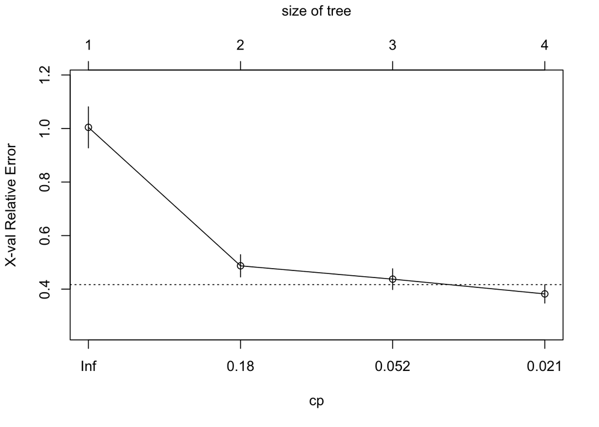

```r
plotcp(fittemp) # Visualize cross-validation results
```

```r
summary(fittemp) # Detailed summary of fit
```

```
## Call:
## rpart(formula = O3 ~ temp, data = ozone)
##   n= 330
##
##           CP nsplit rel error    xerror       xstd
## 1 0.54569932      0 1.0000000 1.0043407 0.07680866
## 2 0.06241925      1 0.4543007 0.4871397 0.04178874
## 3 0.04412234      2 0.3918814 0.4373056 0.03887850
## 4 0.01000000      3 0.3477591 0.3821840 0.03446634
##
## Variable importance
## temp
##  100
##
## Node number 1: 330 observations,    complexity param=0.5456993
##   mean=11.77576, MSE=63.98608
##   left son=2 (214 obs) right son=3 (116 obs)
##   Primary splits:
##       temp < 67.5 to the left,  improve=0.5456993, (0 missing)
##
## Node number 2: 214 observations,    complexity param=0.04412234
##   mean=7.425234, MSE=19.22572
##   left son=4 (138 obs) right son=5 (76 obs)
##   Primary splits:
##       temp < 58.5 to the left,  improve=0.2264444, (0 missing)
##
## Node number 3: 116 observations,    complexity param=0.06241925
##   mean=19.80172, MSE=47.22793
##   left son=6 (72 obs) right son=7 (44 obs)
##   Primary splits:
##       temp < 79.5 to the left,  improve=0.2405809, (0 missing)
##
## Node number 4: 138 observations
##   mean=5.876812, MSE=12.87613
##
## Node number 5: 76 observations
##   mean=10.23684, MSE=18.49654
##
## Node number 6: 72 observations
##   mean=17.16667, MSE=36.47222
##
## Node number 7: 44 observations
##   mean=24.11364, MSE=34.87345
```

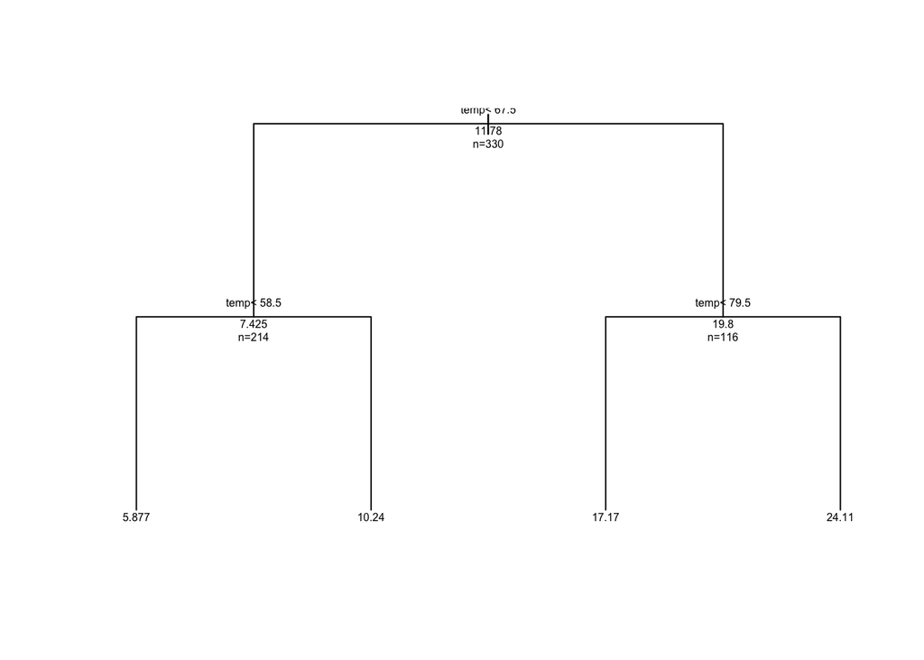

```r
# plot tree
plot(fittemp, uniform = TRUE, compress = FALSE)
text(fittemp, use.n = TRUE, all = TRUE, cex = 0.5)
```

Now we can throw all of the variables in, and see how it partitions:

```r
fitall <- rpart(O3 ~ ., data = ozone)
```

So what does this partition look like?

```r
# Now let's look at fitall
printcp(fitall) # Display the results
```

```
##
## Regression tree:
## rpart(formula = O3 ~ ., data = ozone)
##
## Variables actually used in tree construction:
## [1] doy      dpg      humidity ibh      ibt      temp     vis
##
## Root node error: 21115/330 = 63.986
##
## n= 330
##
##         CP nsplit rel error  xerror     xstd
## 1 0.545699      0   1.00000 1.01011 0.076985
## 2 0.073659      1   0.45430 0.48728 0.042154
## 3 0.053542      2   0.38064 0.44382 0.041571
## 4 0.026756      3   0.32710 0.38205 0.036999
## 5 0.023276      4   0.30034 0.37822 0.036860
## 6 0.023102      5   0.27707 0.37169 0.036502
## 7 0.015325      6   0.25397 0.36569 0.036836
## 8 0.010914      7   0.23864 0.36188 0.037107
## 9 0.010000      8   0.22773 0.35356 0.035576
```

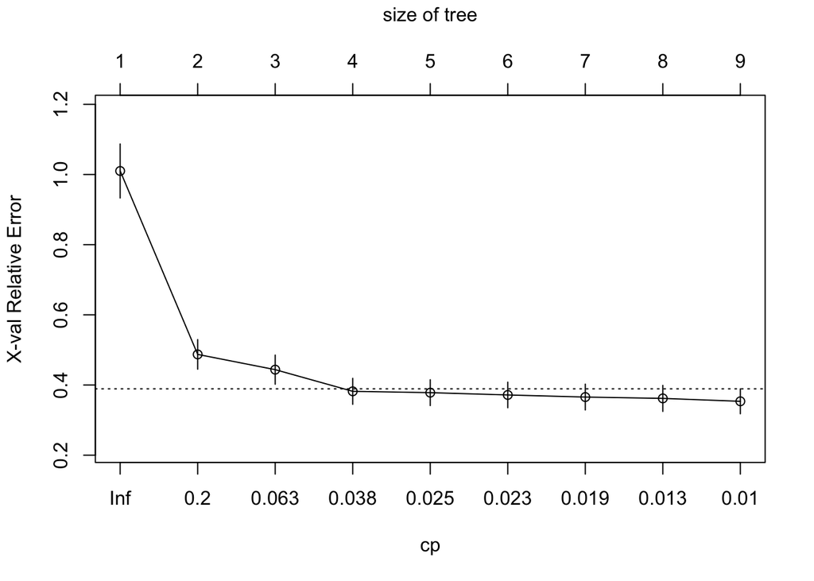

```r
plotcp(fitall) # Visualize cross-validation results
```

```r
summary(fitall) # Detailed summary of fit
```

```
## Call:
## rpart(formula = O3 ~ ., data = ozone)
##   n= 330
##
##           CP nsplit rel error    xerror       xstd
## 1 0.54569932      0 1.0000000 1.0101119 0.07698474
## 2 0.07365906      1 0.4543007 0.4872821 0.04215410
## 3 0.05354155      2 0.3806416 0.4438159 0.04157120
## 4 0.02675573      3 0.3271001 0.3820535 0.03699907
## 5 0.02327600      4 0.3003443 0.3782152 0.03685992
## 6 0.02310206      5 0.2770684 0.3716908 0.03650202
## 7 0.01532492      6 0.2539663 0.3656934 0.03683594
## 8 0.01091366      7 0.2386414 0.3618827 0.03710704
## 9 0.01000000      8 0.2277277 0.3535596 0.03557572
##
## Variable importance
##     temp      ibt       vh      ibh humidity      vis      dpg      doy
##       31       24       20        9        5        5        4        2
##
## Node number 1: 330 observations,    complexity param=0.5456993
##   mean=11.77576, MSE=63.98608
##   left son=2 (214 obs) right son=3 (116 obs)
##   Primary splits:
##       temp < 67.5   to the left,  improve=0.5456993, (0 missing)
##       ibt  < 190.5  to the left,  improve=0.4551252, (0 missing)
##       ibh  < 3472.5 to the right, improve=0.3336499, (0 missing)
##       vh   < 5825   to the left,  improve=0.3237221, (0 missing)
##       vis  < 145    to the right, improve=0.1932240, (0 missing)
##   Surrogate splits:
##       ibt      < 191.5  to the left,  agree=0.870, adj=0.629, (0 split)
##       vh       < 5815   to the left,  agree=0.852, adj=0.578, (0 split)
##       humidity < 70.5   to the left,  agree=0.694, adj=0.129, (0 split)
##       ibh      < 2396   to the right, agree=0.691, adj=0.121, (0 split)
##       vis      < 95     to the right, agree=0.679, adj=0.086, (0 split)
##
## Node number 2: 214 observations,    complexity param=0.05354155
##   mean=7.425234, MSE=19.22572
##   left son=4 (108 obs) right son=5 (106 obs)
##   Primary splits:
##       ibh  < 3573.5 to the right, improve=0.2747856, (0 missing)
```

[output cut: 115 more lines]

```
##       doy      < 266.5  to the left,  agree=0.736, adj=0.176, (0 split)
##       vh       < 5915   to the left,  agree=0.717, adj=0.118, (0 split)
##       dpg      < -0.5   to the right, agree=0.698, adj=0.059, (0 split)
##
## Node number 22: 40 observations
##   mean=9.05, MSE=7.1975
##
## Node number 23: 31 observations
##   mean=14.35484, MSE=18.93861
##
## Node number 30: 36 observations
##   mean=22.94444, MSE=31.94136
##
## Node number 31: 17 observations
##   mean=27.41176, MSE=22.35986
```

And for the plot:

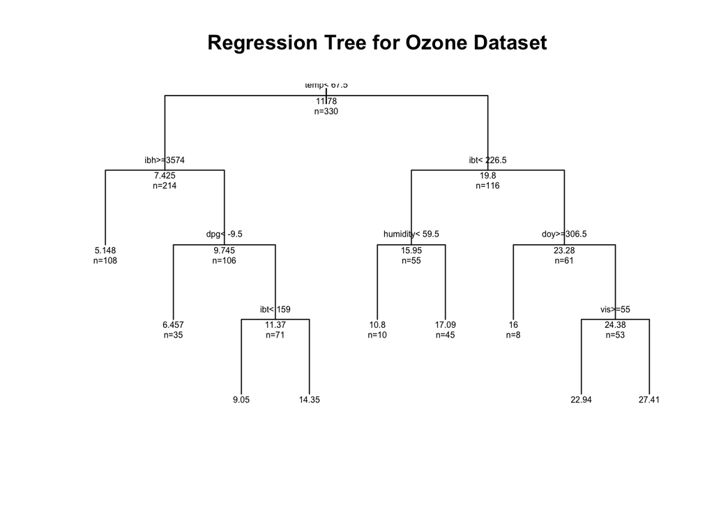

```r
plot(fitall, uniform = TRUE, compress = FALSE, main = "Regression Tree for Ozone Dataset")
text(fitall, use.n = TRUE, all = TRUE, cex = 0.5)
```

Let’s think about pruning the tree now.

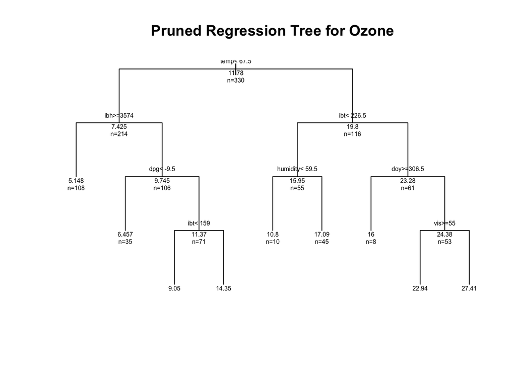

```r
# Prune the tree
pfit <- prune(fitall, cp = fitall$cptable[which.min(fitall$cptable[, "xerror"]), "CP"])

# Plot the pruned tree
plot(pfit, uniform = TRUE, compress = FALSE, main = "Pruned Regression Tree for Ozone")
text(pfit, use.n = TRUE, all = TRUE, cex = 0.5)
```

The package *party* provides nonparametric regression trees, and it also creates better graphics. Let’s giv it a try.

```r
library(party)
```

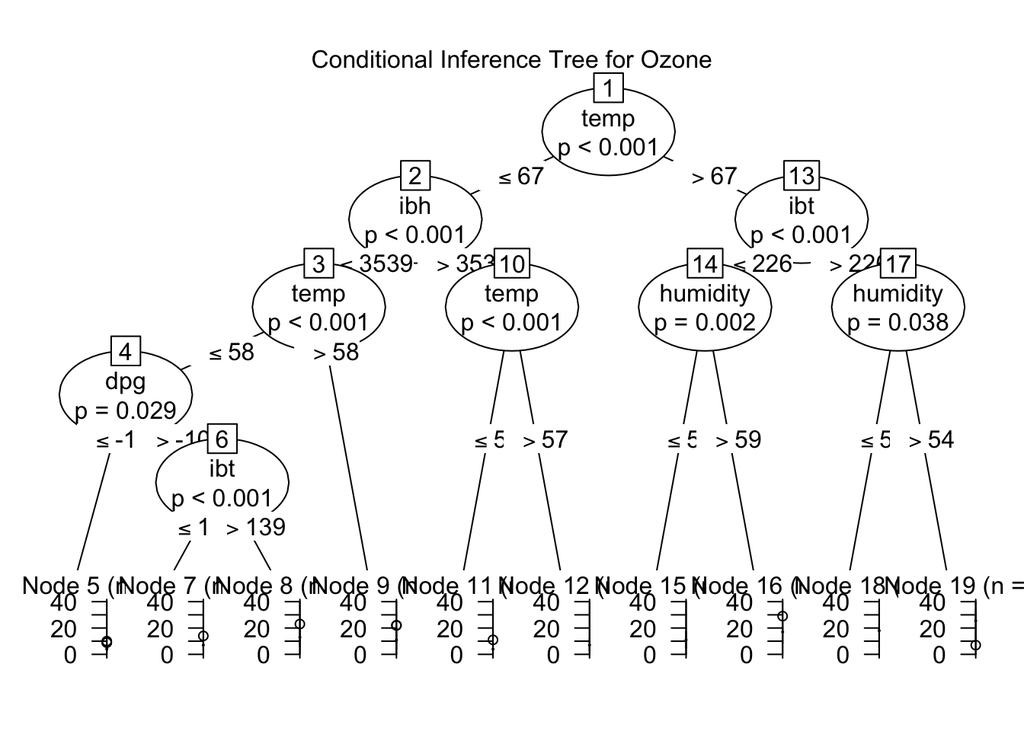

```r
fitallp <- ctree(O3 ~ ., data = ozone)
plot(fitallp, main = "Conditional Inference Tree for Ozone")
```

In this package, tree growth is based on statistical stopping rules, thus pruning shoul not be necessary.

Another type of classifier is a decision tree. This comes from logistic regression. You will recall a couple of weeks ago we talked about the generalized linear model, and logistic regression is one form of such a model.

### Random Forests

Random forests improve predictive accuracy by generating a large number of bootstrapped trees, then averaging across all trees. This is implemented in (what else?) the *randomForest* package.

```r
library(randomForest)
set.seed(131)
# Random Forest for the ozone dataset
fitallrf <- randomForest(O3 ~ ., data = ozone, importance = TRUE)
impallrf <- importance(fitallrf)

# view the results
print(fitallrf)
```

```
##
## Call:
##  randomForest(formula = O3 ~ ., data = ozone, importance = TRUE)
##                Type of random forest: regression
##                      Number of trees: 500
## No. of variables tried at each split: 3
##
##           Mean of squared residuals: 15.93129
##                     % Var explained: 75.1
```

```r
importance(fitallrf)
```

```
##           %IncMSE IncNodePurity
## vh       10.87856     2059.9203
## wind      1.42470      232.3379
## humidity 17.02771     1386.4103
## temp     25.82143     6664.5256
## ibh      17.92247     2357.0199
## dpg      19.55824     1223.7391
## ibt      24.17512     4826.7761
## vis      10.38042      904.7523
## doy      15.16502      993.3406
```